# Exam 1

Sara Whitelaw

10/04/2021

# Instructions

1. Create a folder in your computer (a good place would be under Crim 250, Exams).
2. Download the dataset from the Canvas website (fatal-police-shootings-data.csv) onto that folder, and save your Exam 1.Rmd file in the same folder.
3. Download the README.md file. This is the codebook.
4. Load the data into an R data frame.

```r
dat.shootings <- read.csv("fatal-police-shootings-data.csv")
```

# Problem 1 (10 points)

1. Describe the dataset. This is the source: https://github.com/washingtonpost/data-police-shootings . Write two sentences (max.) about this.

**The data is documents those shootings in which a police officer in the line of duty, shoots and kills a civilian. The variables include a unique itentifier for each victim, the name of each victim, the date of the shooting,manner of death, armed, age, gender, race, city, state, signs of mental illness, threat level, flee, body camera, latitude and longitude, and accuracy of the coordinates.**

```r
names(dat.shootings)
```

```
##  [1] "id"                      "name"
##  [3] "date"                    "manner_of_death"
##  [5] "armed"                   "age"
##  [7] "gender"                  "race"
##  [9] "city"                    "state"
## [11] "signs_of_mental_illness" "threat_level"
## [13] "flee"                    "body_camera"
## [15] "longitude"               "latitude"
## [17] "is_geocoding_exact"
```

3. Look at the names of the variables in the data frame. Describe what “body_camera”, “flee”, and “armed” represent, according to the codebook. Again, only write one sentence (max) per variable.

**body camera indicates whether the officer was wearing a body camera during the incident. flee indicates whether the victim was moving away from the officers by foot, car, or not fleeing. Armed represents whether the victim was armed described by undetermined, unknown, or unarmed.**

4. What are three weapons that you are surprised to find in the “armed” variable? Make a table of the values in “armed” to see the options.

```r
table(dat.shootings$armed)
```

```
##
##                                                   air conditioner
##                              207                                1
##                       air pistol                   Airsoft pistol
##                                1                                3
##                               ax                         barstool
##                               24                                1
##                     baseball bat          baseball bat and bottle
##                               20                                1
## baseball bat and fireplace poker           baseball bat and knife
##                                1                                1
##                            baton                           BB gun
##                                6                               15
##               BB gun and vehicle                     bean-bag gun
##                                1                                1
##                      beer bottle                       binoculars
##                                3                                1
##                     blunt object                           bottle
##                                5                                1
##                    bow and arrow                       box cutter
##                                1                               13
##                            brick              car, knife and mace
##                                2                                1
##                          carjack                            chain
##                                1                                3
##                        chain saw                         chainsaw
##                                2                                1
##                            chair              claimed to be armed
##                                4                                1
##               contractor's level                   cordless drill
##                                1                                1
##                         crossbow                          crowbar
##                                9                                5
##                        fireworks                         flagpole
##                                1                                1
##                       flashlight                      garden tool
##                                2                                2
##                      glass shard                          grenade
##                                4                                1
##                              gun                      gun and car
```

[output cut: 46 more lines]

```
##                                1                                5
##                            sword                            Taser
##                               23                               34
##                        tire iron                       toy weapon
##                                4                              226
##                          unarmed                     undetermined
##                              421                              188
##                   unknown weapon                          vehicle
##                               82                              213
##                  vehicle and gun              vehicle and machete
##                                8                                1
##                    walking stick                       wasp spray
##                                1                                1
##                           wrench
##                                1
```

**I am most shocked to see that there were binoculars, wasp spray, and a walking stick classified as a weapon.**

# Problem 2 (10 points)

1. Describe the age distribution of the sample. Is this what you would expect to see?

```r
summary(dat.shootings$age)
```

```
##    Min. 1st Qu.  Median    Mean 3rd Qu.    Max.    NA's
##    6.00   27.00   35.00   37.12   45.00   91.00     308
```

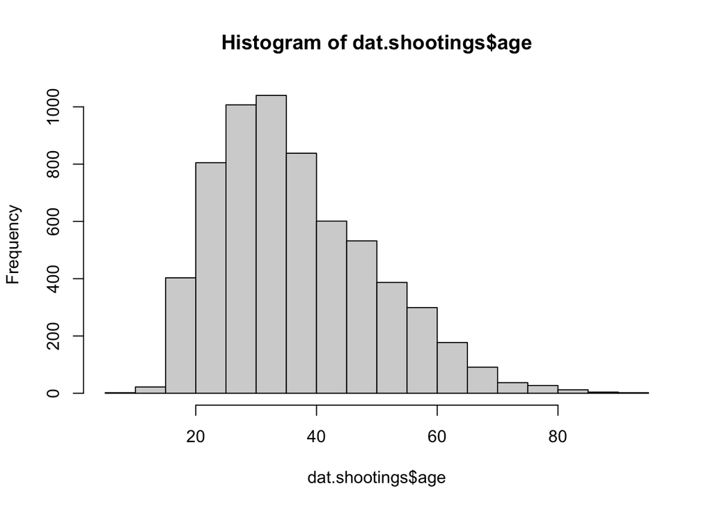

```r
hist(dat.shootings$age)
```

**the minimum age of 6 and maximum age of 91 are the most shocking variables as one cannot understand how someone at that age can be seen as a threat to a police officer. The mean of the sample is 37.12, median is 35. The first quartile is at 27 yrs and the 3rd is at 45. The histogram shows a right skew of the data, with most of the data centered around the middle ages which is expected**

2. To understand the center of the age distribution, would you use a mean or a median, and why? Find the one you picked.

**the center of the age distribution is understood by the median. Since the data is not evenly distributed, rather has a right skew, the median will be a better representative of the middle of the data. Median is not affected by the numerical values of the outliers. The median of the data is 35 years old.**

3. Describe the gender distribution of the sample. Do you find this surprising?

```r
dat.shootings$gender
```

[output not shown]

[output cut: 352 more lines]

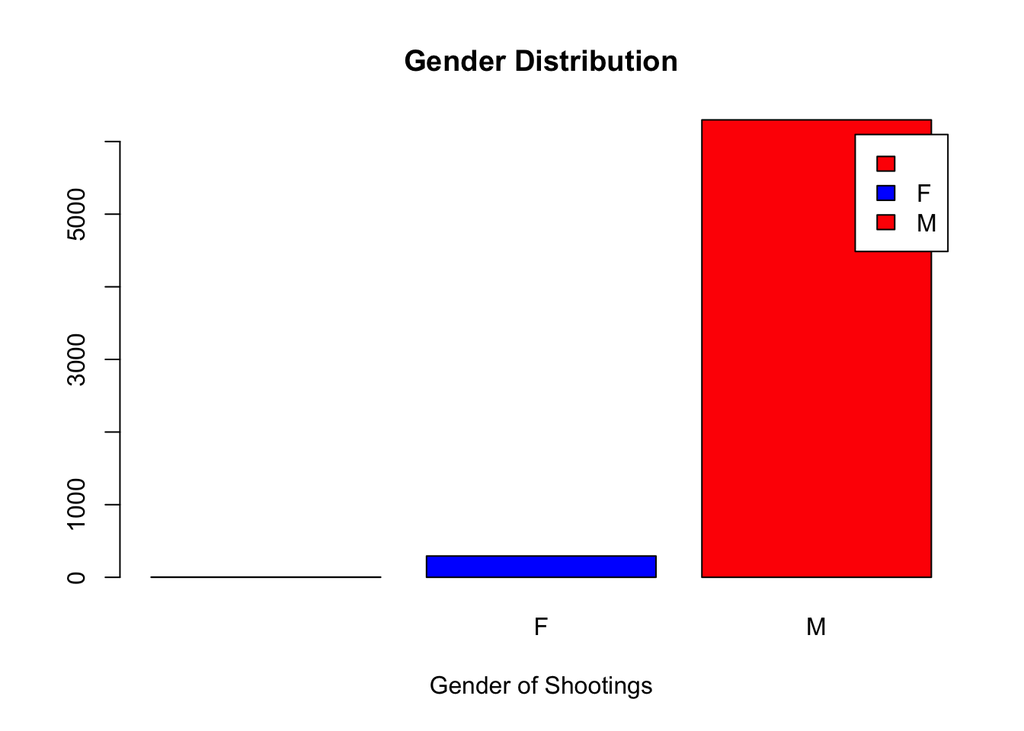

```r
counts <- table(dat.shootings$gender)
barplot(counts, main = "Gender Distribution", xlab = "Gender of Shootings", col=c("red", "blue"),
        legend=TRUE)
```

**the gender distribution is extremely heavier on the males than the females. This is not surprising because males are probably seen as more of a threat to male police officers.**

# Problem 3 (10 points)

1. How many police officers had a body camera, according to news reports? What proportion is this of all the incidents in the data? Are you surprised that it is so high or low?

```r
library(janitor)
tabyl(dat.shootings$body_camera)
```

```
##  dat.shootings$body_camera    n   percent
##                      False 5684 0.8619958
##                       True  910 0.1380042
```

**910 police officers had a body camera according to news reports. This is only 13% of all the incidents in the data. I am surprised that it is so low because I thought that the use of body cameras would be more regulated.**

2. In how many of the incidents was the victim fleeing? What proportion is this of the total number of incidents in the data? Is this what you would expect?

```r
tabyl(dat.shootings$flee)
```

```
##  dat.shootings$flee    n    percent
##                      491 0.07446163
##                 Car 1058 0.16044889
##                Foot  845 0.12814680
##         Not fleeing 3952 0.59933273
##               Other  248 0.03760995
```

**There were 1903 incidents of the victim fleeing making up around 30% of the total incidents. However we must account for the fact that there are 491 instances of missing data (N/A) which could influence this number if it were included. My expectation, however, would be that there are more individuals fleeing rather than not if they are being fatally shot.**

# Problem 4 (10 points) - Answer only one of these (a or b).

1. Describe the relationship between the variables “body camera” and “flee” using a stacked barplot. What can you conclude from this relationship?

*Hint 1: The categories along the x-axis are the options for “flee”, each bar contains information about whether the police officer had a body camera (vertically), and the height along the y-axis shows the frequency of that category).*

*Hint 2: Also, if you are unsure about the syntax for barplot, run ?barplot in R and see some examples at the bottom of the documentation. This is usually a good way to look up the syntax of R code. You can also Google it.*

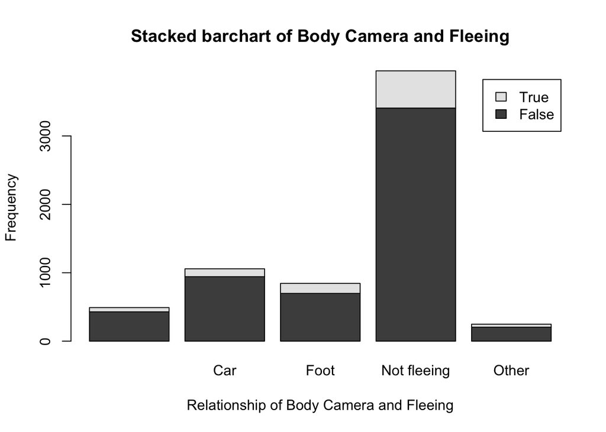

```r
tab.bodycamflee <- table(dat.shootings$body_camera, dat.shootings$flee)
barplot(tab.bodycamflee,
        main = "Stacked barchart of Body Camera and Fleeing",
        xlab = "Relationship of Body Camera and Fleeing", ylab = "Frequency",
        legend.text = rownames(tab.bodycamflee),
        beside = FALSE) # Stacked bars (default)
```

**This relationship is alarming in that the majority of fatal shootings occurred when the victim was not fleeing and the officer was not wearing a body camera. In the majority of all categories for fleeing, the majority of officers are not wearing bodycameras.**

2. Describe the relationship between age and race by using a boxplot. What can you conclude from this relationship?

*Hint 1: The categories along the x-axis are the race categories and the height along the y-axis is age.*

*Hint 2: Also, if you are unsure about the syntax for boxplot, run ?boxplot in R and see some examples at the bottom of the documentation. This is usually a good way to look up the syntax of R code. You can also Google it.*

```r
table(dat.shootings$race)
```

```
##
##         A    B    H    N    O    W
##  752  106 1553 1083   91   47 2962
```

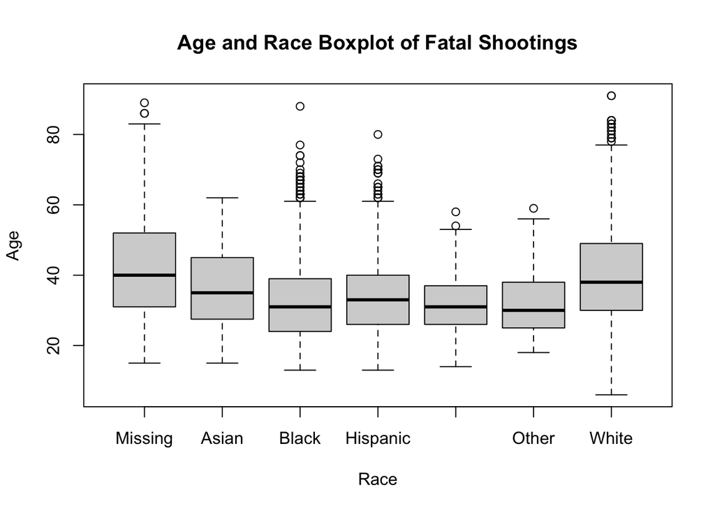

```r
plot(factor(dat.shootings$race), dat.shootings$age, ylab="Age", xlab="Race",
     names=c("Missing","Asian", "Black", "Hispanic", "Native American", "Other", "White"),
     main = "Age and Race Boxplot of Fatal Shootings")
```

**There are missing values located in the barplot which must be accounted for. This relationship shows that most of the fatal shootings for each race are occuring around the same age**

# Extra credit (10 points)

1. What does this code tell us?

```r
mydates <- as.Date(dat$date)
head(mydates)
(mydates[length(mydates)] - mydates[1])
```

2. On Friday, a new report was published that was described as follows by The Guardian: “More than half of US police killings are mislabelled or not reported, study finds.” Without reading this article now (due to limited time), why do you think police killings might be mislabelled or underreported?
3. Regarding missing values in problem 4, do you see any? If so, do you think that’s all that’s missing from the data?